# Praktikum 2 Anreg

Abdullah’ Ammar Rabbaniyyin

2026-02-09

# Data

## Membaca Data

```r
library(readxl)
data <- read_excel("D:\\My Documents\\Downloads\\NSC-2025.xlsx", sheet="Sheet2")
head(data)
```

```
## # A tibble: 6 × 24
##   `Kabupaten/Kota`     `Indeks Pembangunan Manusia` `Rata-Rata Lama Sekolah`
##   <chr>                                       <dbl>                    <dbl>
## 1 Kepulauan Seribu                             76.7                     9.26
## 2 Kota Jakarta Selatan                         87.6                    12.0
## 3 Kota Jakarta Timur                           84.8                    12.0
## 4 Kota Jakarta Pusat                           83.8                    11.6
## 5 Kota Jakarta Barat                           84.4                    11.2
## 6 Kota Jakarta Utara                           82.1                    10.8
## # ℹ 21 more variables: `PDRB ADHK (MILYAR RUPIAH)` <dbl>,
## #   `Persentase Penduduk Miskin` <dbl>,
## #   `Persentase Akses Sanitasi Layak` <dbl>,
## #   `Kontribusi Sektor Industri Pengolahan teradap PDRB/PDB  (%)` <dbl>,
## #   `Pertumbuhan Ekonomi Sektor Industri Pengolahan` <dbl>,
## #   `Indeks Pembangunan Gender` <dbl>,
## #   `Tingkat Partisipasi Angkatan Kerja (TPAK)` <dbl>, …
```

## Menyesuaikan Peubah

```r
colnames(data) <- c("Kabupaten/Kota", "Y", paste0("X", 1:9))
head(data)
```

```
## # A tibble: 6 × 24
##   `Kabupaten/Kota`      Y    X1     X2    X3    X4    X5    X6    X7    X8    X9
##   <chr>             <dbl> <dbl>  <dbl> <dbl> <dbl> <dbl> <dbl> <dbl> <dbl> <dbl>
## 1 Kepulauan Seribu   76.7  9.26 3.27e3 13.0   89.1  4.06  0.37  93.6  72.6  7.93
## 2 Kota Jakarta Sel…  87.6 12.0  5.00e5  3.03  92.6  1.38  3.74  97.3  64.8  5.22
## 3 Kota Jakarta Tim…  84.8 12.0  3.62e5  4.09  97.2 26.7   2.13  95.9  64.5  6.95
## 4 Kota Jakarta Pus…  83.8 11.6  5.33e5  4.63  90.3  0.84  0.01  96.2  65.1  6.24
## 5 Kota Jakarta Bar…  84.4 11.2  3.83e5  3.94  94.9  5.3   2.16  95.7  64.1  6.18
## 6 Kota Jakarta Uta…  82.1 10.8  3.80e5  6.44  91.4 30.3   0.52  94.4  67.8  6.18
## # ℹ 13 more variables: `` <lgl>, `` <lgl>, `` <lgl>, `` <lgl>, `` <lgl>,
## #   `` <lgl>, `` <lgl>, `` <lgl>, `` <lgl>, `` <lgl>, `` <lgl>, `` <lgl>,
## #   `` <lgl>
```

# Eksplorasi Data

```r
n <- nrow(data)
```

Saat ini terdapat 1 peubah Y dan 9 peubah X, misal ingin dilakukan eksplorasi dan analisis terkait peubah X6

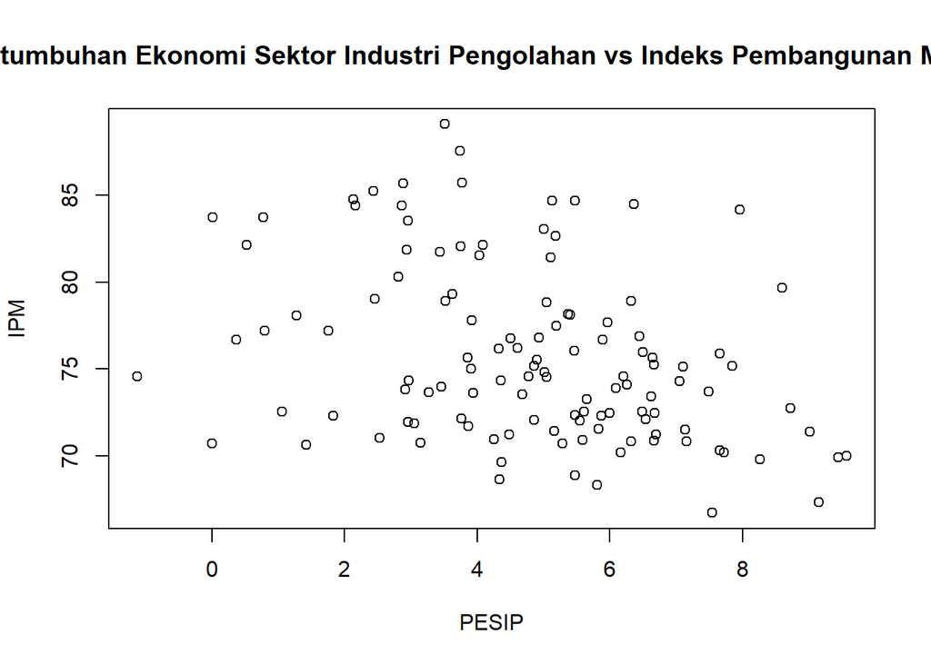

```r
plot(data$X6, data$Y,
     main = "Pertumbuhan Ekonomi Sektor Industri Pengolahan vs Indeks Pembangunan Manusia",
     xlab = "PESIP",
     ylab = "IPM")
```

```r
summary(data$Y)
```

```
##    Min. 1st Qu.  Median    Mean 3rd Qu.    Max.
##   66.72   71.91   74.57   75.75   78.86   89.10
```

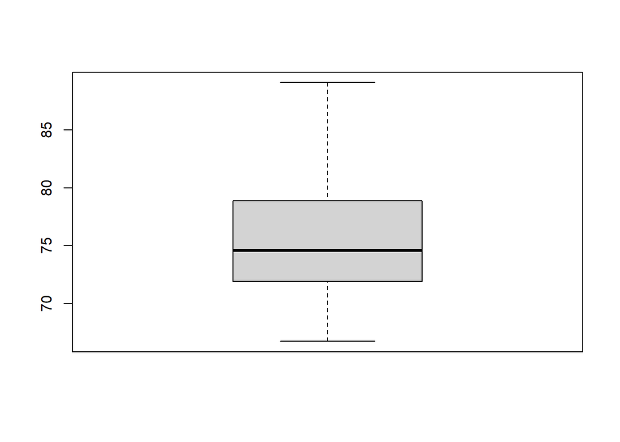

```r
boxplot(data$Y)
```

```r
summary(data$X6)
```

```
##    Min. 1st Qu.  Median    Mean 3rd Qu.    Max.
##  -1.130   3.485   5.010   4.823   6.320   9.570
```

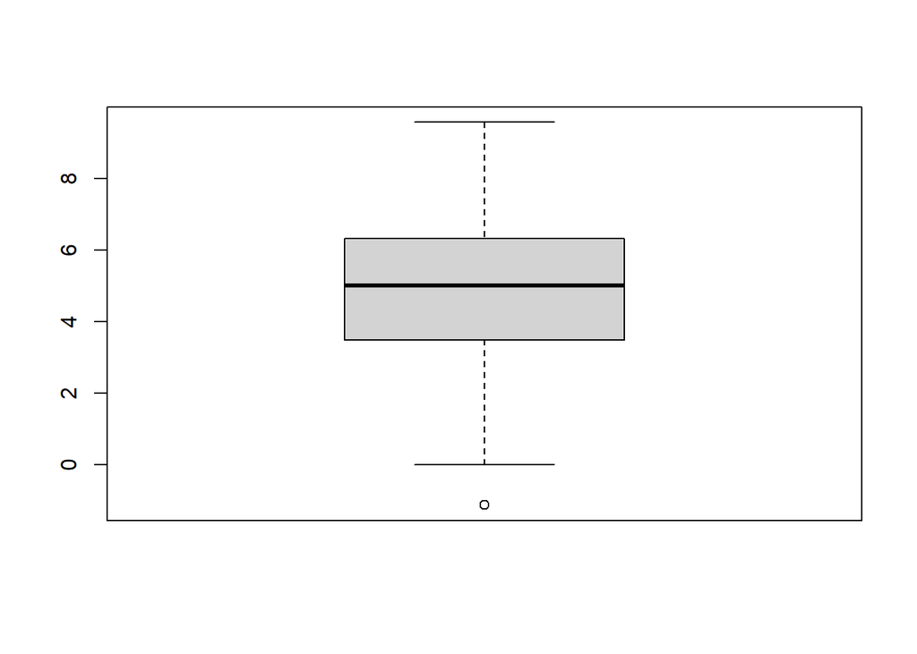

```r
boxplot(data$X6)
```

# Pembentukan Model

## Manual

### Koefisien Regresi

$\hat{y_i} = \hat{\beta_0} + \hat{\beta_1} x_{i}, i = 1,2, ..., n$ $\hat{\beta}_1 = \frac{\sum (x_i - \bar{x})(y_i - \bar{y})} {\sum (x_i - \bar{x})^2} = \frac{S_{xy}}{S_{xx}}$ $\hat{\beta_1} = \frac{\sum (x_iy)-\frac{\sum(x_i)\sum(y)}{n}}{\sum(x_i^2)-\frac{\sum(x_i^2)}{n}}$ $\hat{\beta_0} = \bar{y} - \hat{\beta_1} \bar{x}$

```r
x <- data$X6
y <- data$Y
```

```r
b1 <- (sum(x*y)-sum(x)*sum(y)/n)/(sum(x^2)-(sum(x)^2/n))
b0 <- mean(y)-b1*mean(x)

cat("Koefisien b0:", b0, "\n")
```

```
## Koefisien b0: 79.71166
```

```r
cat("Koefisien b1:", b1, "\n")
```

```
## Koefisien b1: -0.8221789
```

### Standar Error Parameter Regresi

Standar error menunjukan seberapa besar ketidakpastian dalam estimasi koefisien

```r
galat <- y-(b0+b1*x)
ragam_galat <- sum(galat^2)/(n-2)

se_b0 <- sqrt(ragam_galat*(1/n+mean(x)^2/sum((x-mean(x))^2)))
se_b1 <- sqrt(ragam_galat/sum((x-mean(x))^2))

cat("Standar error b0:", se_b0, "\n")
```

```
## Standar error b0: 1.054198
```

```r
cat("Standar error b1:", se_b1, "\n")
```

```
## Standar error b1: 0.1994159
```

### Signifikansi Parameter (nilai-t)

Nilai ini menunjukkan tingkat signifikansi secara parsial dari setiap koefisien peubah berdasarkan nilai t dan probabilitas nilai p

```r
t_b0 <- b0/se_b0
t_b1 <- b1/se_b1
p_b0 <- 2*pt(-abs(t_b0 ),df<-n-2)
p_b1 <- 2*pt(-abs(t_b1 ),df<-n-2)

cat("Nilai t pada b0 adalah", t_b0, "dengan nilai p sebesar", p_b0, "\n")
```

```
## Nilai t pada b0 adalah 75.61359 dengan nilai p sebesar 3.542193e-101
```

```r
cat("Nilai t pada b1 adalah", t_b1, "dengan nilai p sebesar", p_b1, "\n")
```

```
## Nilai t pada b1 adalah -4.122935 dengan nilai p sebesar 7.022546e-05
```

Nilai p kurang dari alpha 0.05 untuk b0 maupun b1 sehingga signifikan pada taraf nyata 5%

### Koefisien Determinasi dan Penyesuaiannya

Pada analisis regresi linier sederhana, koefisien determinasi yang digunakan adalah multiple R Squared, sedangkan regresi linier berganda menggunakan adjusted R Squared yang disesuaikan dengan banyaknya peubah

```r
r <- (sum(x*y)-sum(x)*sum(y)/n)/
sqrt((sum(x^2)-(sum(x)^2/n))*(sum(y^2)-(sum(y)^2/n)))
Koef_det <- r^2
Koef_det
```

```
## [1] 0.1268565
```

```r
Adj_R2 <- 1-((1-Koef_det)*(n-1)/(n-1-1))
Adj_R2
```

```
## [1] 0.1193938
```

### Signifikansi Simultan (F)

Nilai ini menunjukkan signifikansi dan kebaikan model secara simultan (bersamaan seluruh peubah) yang menjelaskan model secara keseluruhan memiliki hubungan berarti antara X dan Y

```r
galat<-y-(b0+b1*x)

JKG <- sum((y - (b0+b1*x))^2)
JKReg <- sum(((b0+b1*x)- mean(y))^2)
JKT <- sum((y - mean(y))^2)
JKT <- JKReg+JKG

dbReg <- 1
dbg <- n-2
dbt <- n-1

(Fhit <- (JKReg/dbReg)/(JKG/dbg))
```

```
## [1] 16.9986
```

```r
(p_Fhit <- 1-pf(Fhit, dbReg, dbg, lower.tail = F))
```

```
## [1] 0.9999298
```

## Menggunakan Fungsi `lm()`

```r
model <- lm(Y~X6, data = data)
summary(model)
```

```
##
## Call:
## lm(formula = Y ~ X6, data = data)
##
## Residuals:
##     Min      1Q  Median      3Q     Max
## -8.9917 -3.1625 -0.8288  2.8420 12.2742
##
## Coefficients:
##             Estimate Std. Error t value Pr(>|t|)
## (Intercept)  79.7117     1.0542  75.614  < 2e-16 ***
## X6           -0.8222     0.1994  -4.123 7.02e-05 ***
## ---
## Signif. codes:  0 '***' 0.001 '**' 0.01 '*' 0.05 '.' 0.1 ' ' 1
##
## Residual standard error: 4.708 on 117 degrees of freedom
## Multiple R-squared:  0.1269, Adjusted R-squared:  0.1194
## F-statistic:    17 on 1 and 117 DF,  p-value: 7.023e-05
```

```r
anova(model)
```

```
## Analysis of Variance Table
##
## Response: Y
##            Df  Sum Sq Mean Sq F value    Pr(>F)
## X6          1  376.72  376.72  16.999 7.023e-05 ***
## Residuals 117 2592.91   22.16
## ---
## Signif. codes:  0 '***' 0.001 '**' 0.01 '*' 0.05 '.' 0.1 ' ' 1
```

# Kesimpulan

Model yang terbentuk adalah sebagai berikut:

dengan Y adalah nilai Indeks Pembangunan Manusia dan X6 adalah Pertumbuhan Ekonomi Sektor Industri Pengolahan.

Koefisien determinasi yang dihasilkan adalah 0.1268565 atau 12,69% artinya keragaman Indeks Pembangunan Manusia yang dapat dijelaskan oleh nilai pertumbuhan ekonomi sektor industri pengolahan adalah sebesar 12,69%, sisanya yaitu 87,31% dijelaskan oleh peubah lain yang tidak dimasukkan dalam model.